# DATS 6101 Team 1 - Project 2

Tyler Wallett, Anushka Vuppala and David Li

2022-12-15

# Introduction

Our research topic aims to perform explorartory data analysis on the Nearest Earth Objects (NEO) dataset recorded by NASA. This particular dataset includes thousands of labeled observations, over the last 22 years, across multiple attributes that each aim to describe a specific object. Borrowing from the humor of the recent film *Don’t Look Up* by Adam Mckay and NASA’s success in the Double Asteroid Redirection Test (DART) mission, we thought that further describing and exploring this dataset would be opportune.

The EDA performed can help with the early detection of an asteroid. With the early detection, NASA can take quick remedies to help eliminate the threat. NASA’s *DART* mission (Double Asteroid Redirection Test) was done for the same purpose. It was designed to deflect an asteroid with a certain momentum by hitting it head-on or attempting to slow it down. More can be read online from this [article](https://en.wikipedia.org/wiki/Double_Asteroid_Redirection_Test).

According to NASA’s [official documentation](https://cneos.jpl.nasa.gov/about/neo_groups.html), a PHA is technically termed using parameters that measure the asteroid’s characteristics and then make a decision if the asteroid is considered hazardous based on certain thresholds. Specifically, all asteroids with an Earth Minimum Orbit intersection Distance (MOID) of 0.05 au or less and an absolute magnitude (H) of 22.0 or less are considered Potentially Hazardous Asteroids (PHAs). In other words, asteroids that can’t get any closer to the Earth (i.e., MOID) than 0.05 au (roughly 7,480,000km) or are smaller than about 140m in diameter (i.e., H=22.0) are not considered PHAs.

The current dataset that we have contains 90,000 rows. Each row represents a NEO identified by an ID and name. Out of these 90,000 rows, 9,000 of them are hazardous and 81,000 of them are non-hazardous. This dataset does not contain null values. Apart from the hazardous target variable, our dataset contains 5 numerical variables that can help identify if the asteroid is hazardous or not. These 5 variables are:

1. est_diameter_min (km) – estimated minimum diameter of the NEO
2. est_diameter_max (km) – estimated maximum diameter of the NEO
3. relative_velocity – the velocity (in km/seconds) with which the NEO was travelling with respect to Earth
4. miss_distance – distance (in km) by which the asteroid missed the Earth’s surface
5. absolute_magnitude (H) – signifies the brightness of the asteroid

Out of these 5 variables, we have 3 variables that play a primary role in determining if the asteroid was harmful or not. Those are:

1. relative_velocity
2. miss_distance
3. absolute_magnitude

Throughout the rest of this RMD file, we go over each of these 3 variables in complete depth to answer our SMART question – what are some of the statistical characteristics of Nearest Earth Objects, over the last 22 years, in terms of relative velocity, miss distance and absolute magnitude, that make them hazardous or not?

Decision Trees are a type of nonparametric supervised machine learning algo that work to form categorical and/or quantitative predictors. In many ways, they do exactly what they sound like: allow the reader to decide on the probability of certain outcomes based on concurrent and previous criteria.

One advantage of using trees is the ease-of-use: with minimal explanation, anyone can follow along the “branches.”

Trees are also resistant to outliers, and can be evaluated for their “data-worthiness” by industry-standard metrics of accuracy, precision, recall, and ROC/AUC.

Some disadvantages to use of trees include chance of overfitting the data and the largest trees may be unwieldy.

The following code begins by plotting a simple classification tree and showing the size of the relative “x-value” error.

```r
install.packages("rpart", repos='http://cran.us.r-project.org') # Classification trees, rpart(formula, data=, method=,control=)
library(rpart)
```

```r
set.seed(1)
neo <- read.csv("neo.csv")
neofit <- rpart(hazardous ~  absolute_magnitude + miss_distance + relative_velocity, data=neo, method="class", control = list(maxdepth = 4) )
printcp(neofit) # display the results
```

```
##
## Classification tree:
## rpart(formula = hazardous ~ absolute_magnitude + miss_distance +
##     relative_velocity, data = neo, method = "class", control = list(maxdepth = 4))
##
## Variables actually used in tree construction:
## [1] absolute_magnitude miss_distance
##
## Root node error: 8840/90836 = 0.097318
##
## n= 90836
##
##         CP nsplit rel error  xerror      xstd
## 1 0.050396      0   1.00000 1.00000 0.0101051
## 2 0.010000      2   0.89921 0.90011 0.0096386
```

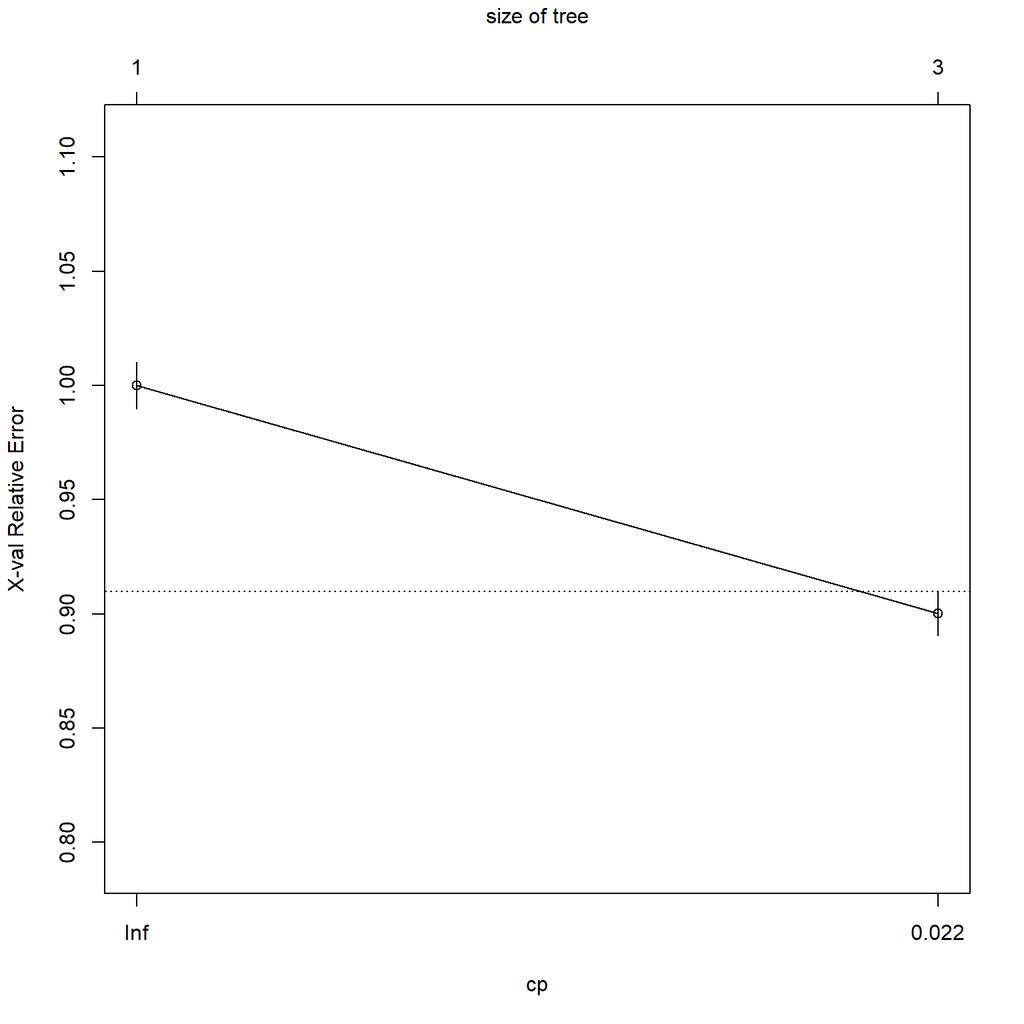

```r
plotcp(neofit) # visualize cross-validation results
```

```r
summary(neofit) # detailed summary of splits
```

```
## Call:
## rpart(formula = hazardous ~ absolute_magnitude + miss_distance +
##     relative_velocity, data = neo, method = "class", control = list(maxdepth = 4))
##   n= 90836
##
##           CP nsplit rel error    xerror        xstd
## 1 0.05039593      0 1.0000000 1.0000000 0.010105114
## 2 0.01000000      2 0.8992081 0.9001131 0.009638638
##
## Variable importance
## absolute_magnitude      miss_distance  relative_velocity
##                 75                 17                  8
##
## Node number 1: 90836 observations,    complexity param=0.05039593
##   predicted class=False  expected loss=0.09731824  P(node) =1
##     class counts: 81996  8840
##    probabilities: 0.903 0.097
##   left son=2 (61572 obs) right son=3 (29264 obs)
##   Primary splits:
##       absolute_magnitude < 22.055   to the right, improve=3542.03200, (0 missing)
##       relative_velocity  < 42803.1  to the left,  improve= 373.81880, (0 missing)
##       miss_distance      < 4775321  to the left,  improve=  93.49669, (0 missing)
##   Surrogate splits:
##       relative_velocity < 77638.26 to the left,  agree=0.711, adj=0.104, (0 split)
##       miss_distance     < 74746720 to the left,  agree=0.678, adj=0.000, (0 split)
##
## Node number 2: 61572 observations
##   predicted class=False  expected loss=0.001055675  P(node) =0.677837
##     class counts: 61507    65
##    probabilities: 0.999 0.001
##
## Node number 3: 29264 observations,    complexity param=0.05039593
##   predicted class=False  expected loss=0.2998565  P(node) =0.322163
##     class counts: 20489  8775
##    probabilities: 0.700 0.300
##   left son=6 (27955 obs) right son=7 (1309 obs)
##   Primary splits:
##       miss_distance      < 11367830 to the right, improve=800.57590, (0 missing)
##       relative_velocity  < 21304.08 to the left,  improve=180.58140, (0 missing)
##       absolute_magnitude < 19.625   to the left,  improve= 54.86017, (0 missing)
##
## Node number 6: 27955 observations
##   predicted class=False  expected loss=0.2745484  P(node) =0.3077524
##     class counts: 20280  7675
##    probabilities: 0.725 0.275
##
## Node number 7: 1309 observations
##   predicted class=True   expected loss=0.1596639  P(node) =0.01441059
##     class counts:   209  1100
##    probabilities: 0.160 0.840
```

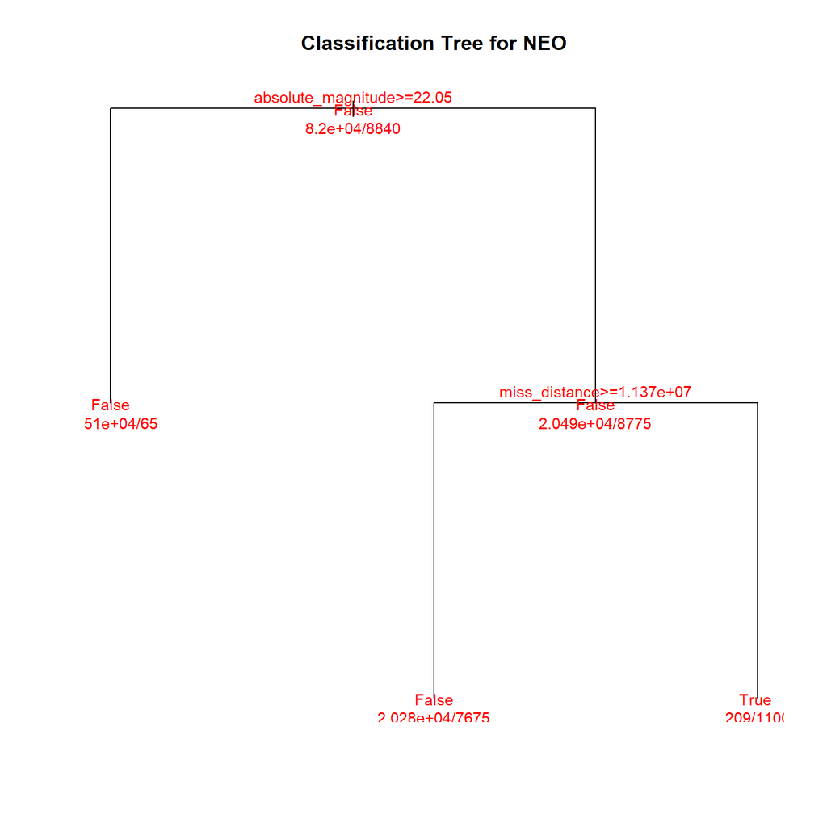

```r
# plot tree
plot(neofit, uniform=TRUE, main="Classification Tree for NEO")
text(neofit, use.n=TRUE, all=TRUE, cex=0.9, col="red")
```

The following code allows to generate a post-script file.

```r
post(neofit, file = "neoTree.ps", title = "Classification Tree for NEO")
```

```r
install.packages("caret", repos='http://cran.us.r-project.org')
library(caret)
neo[,'hazardous'] <- as.factor(neo[,'hazardous'])
cm = confusionMatrix( predict(neofit, type = "class"), reference = neo[, "hazardous"] )
xkabledply(cm$table, "confusion matrix")
```

confusion matrix

|  | False | True |
| --- | --- | --- |
| False | 81787 | 7740 |
| True | 209 | 1100 |

```r
print('Overall: ')
```

```
## [1] "Overall: "
```

```r
cm$overall
```

```
##       Accuracy          Kappa  AccuracyLower  AccuracyUpper   AccuracyNull
##   9.124906e-01   1.966017e-01   9.106343e-01   9.143206e-01   9.026818e-01
## AccuracyPValue  McnemarPValue
##   2.174723e-24   0.000000e+00
```

```r
print('Class: ')
```

```
## [1] "Class: "
```

```r
cm$byClass
```

```
##          Sensitivity          Specificity       Pos Pred Value
##            0.9974511            0.1244344            0.9135456
##       Neg Pred Value            Precision               Recall
##            0.8403361            0.9135456            0.9974511
##                   F1           Prevalence       Detection Rate
##            0.9536564            0.9026818            0.9003809
## Detection Prevalence    Balanced Accuracy
##            0.9855894            0.5609427
```

The following code to create the confusion matrix allows for detailed interpretation of accuracy, sensitivity, specificity, predicted value in either direction, and the level of precision. We are able to create a “fancy” plot using rattle.

```r
confusionMatrixResultDf = data.frame( Depth=numeric(0), Accuracy= numeric(0), Sensitivity=numeric(0), Specificity=numeric(0), Pos.Pred.Value=numeric(0), Neg.Pred.Value=numeric(0), Precision=numeric(0), Recall=numeric(0), F1=numeric(0), Prevalence=numeric(0), Detection.Rate=numeric(0), Detection.Prevalence=numeric(0), Balanced.Accuracy=numeric(0), row.names = NULL )

for (deep in 2:6) {
neofit2 <- rpart(hazardous ~  absolute_magnitude + miss_distance + relative_velocity, data=neo, method="class", control = list(maxdepth = deep) )
cm2 = confusionMatrix( predict(neofit2, type = "class"), reference = neo[, "hazardous"] )
 cmaccu = cm2$overall['Accuracy']
 cmt = data.frame(Depth=deep, Accuracy = cmaccu, row.names = NULL )
cmt = cbind( cmt, data.frame( t(cm$byClass) ) )
 confusionMatrixResultDf = rbind(confusionMatrixResultDf, cmt)
}
```

```r
xkabledply(confusionMatrixResultDf, title="NEO Classification Trees with Varying Max Depth")
```

NEO Classification Trees with Varying Max Depth

| Depth | Accuracy | Sensitivity | Specificity | Pos.Pred.Value | Neg.Pred.Value | Precision | Recall | F1 | Prevalence | Detection.Rate | Detection.Prevalence | Balanced.Accuracy |
| --- | --- | --- | --- | --- | --- | --- | --- | --- | --- | --- | --- | --- |
| 2 | 0.9125 | 0.9975 | 0.1244 | 0.9135 | 0.8403 | 0.9135 | 0.9975 | 0.9537 | 0.9027 | 0.9004 | 0.9856 | 0.5609 |
| 3 | 0.9125 | 0.9975 | 0.1244 | 0.9135 | 0.8403 | 0.9135 | 0.9975 | 0.9537 | 0.9027 | 0.9004 | 0.9856 | 0.5609 |
| 4 | 0.9125 | 0.9975 | 0.1244 | 0.9135 | 0.8403 | 0.9135 | 0.9975 | 0.9537 | 0.9027 | 0.9004 | 0.9856 | 0.5609 |
| 5 | 0.9125 | 0.9975 | 0.1244 | 0.9135 | 0.8403 | 0.9135 | 0.9975 | 0.9537 | 0.9027 | 0.9004 | 0.9856 | 0.5609 |
| 6 | 0.9125 | 0.9975 | 0.1244 | 0.9135 | 0.8403 | 0.9135 | 0.9975 | 0.9537 | 0.9027 | 0.9004 | 0.9856 | 0.5609 |

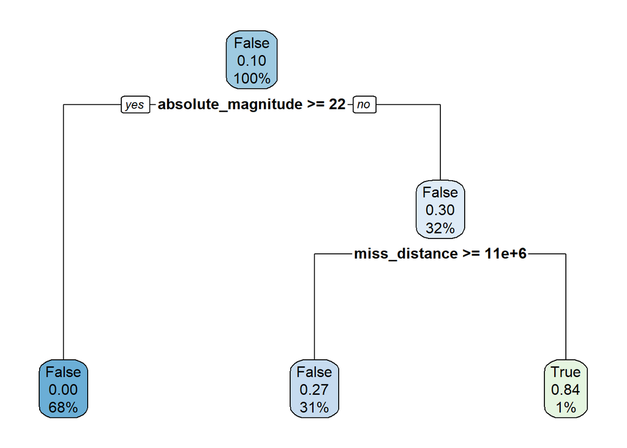

```r
install.packages("rpart.plot", repos='http://cran.us.r-project.org')
library(rpart.plot)
install.packages("rattle", repos='http://cran.us.r-project.org')
library(rattle)
rpart.plot(neofit)
```

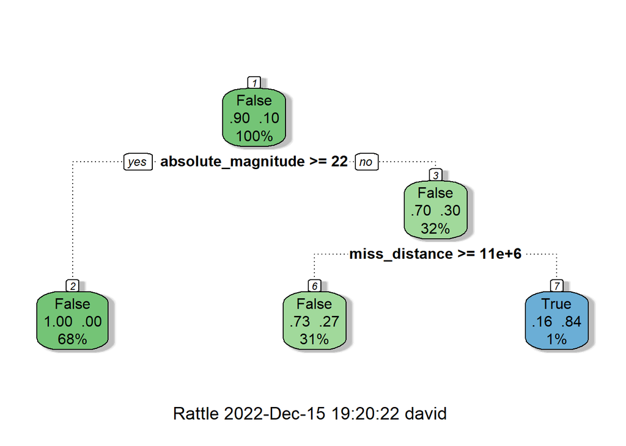

```r
fancyRpartPlot(neofit)
```

```r
install.packages("ISLR",repos='http://cran.us.r-project.org')
library(ISLR)
install.packages("tree",repos='http://cran.us.r-project.org')
library("tree")
treefit <- tree(log(miss_distance) ~ relative_velocity  + absolute_magnitude, data=neo)
summary(treefit)
```

```
##
## Regression tree:
## tree(formula = log(miss_distance) ~ relative_velocity + absolute_magnitude,
##     data = neo)
## Number of terminal nodes:  4
## Residual mean deviance:  1.108 = 100700 / 90830
## Distribution of residuals:
##    Min. 1st Qu.  Median    Mean 3rd Qu.    Max.
## -8.0640 -0.4353  0.2709  0.0000  0.6564  1.8440
```

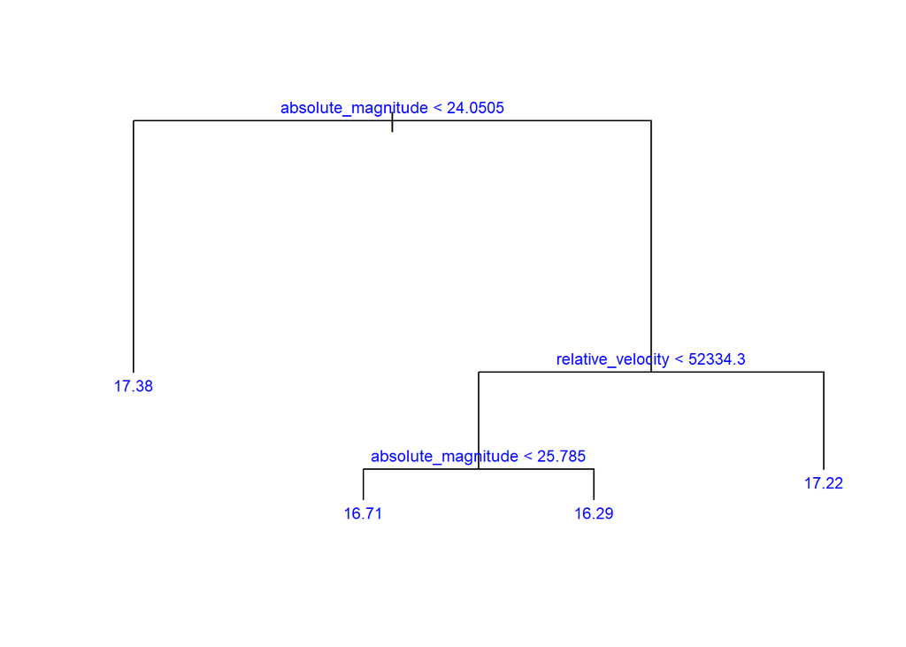

```r
plot(treefit)
text(treefit,cex=0.75, col="blue")
```

# References:

- Kaggle Dataset (Kaggle): Vani, S. (2022, June 17). NASA - Nearest Earth objects. Kaggle. Retrieved November 2, 2022, from https://www.kaggle.com/datasets/sameepvani/nasa-nearest-earth-objects
- Center for Near Earth Objects Studies (CNEOS): NASA. (n.d.). Neo basics. NASA. Retrieved November 2, 2022, from https://cneos.jpl.nasa.gov/about/neo_groups.html
- NASA (NASA): Bardan, R. (2022, October 11). NASA confirms Dart Mission Impact Changed Asteroid’s motion in space. NASA. Retrieved November 2, 2022, from https://www.nasa.gov/press-release/nasa-confirms-dart-mission-impact-changed-asteroid-s-motion-in-space
- Araujo, R. A. N., & Winter, O. C. (2014). Near-Earth asteroid binaries in close encounters with the Earth. Astronomy & Astrophysics, 566, A23.
- Peter O. K. Krehl (2008). History of Shock Waves, Explosions and Impact: A Chronological and Biographical Reference. Springer Science & Business Media. p. 404. ISBN 978-3-540-30421-0.
- Tonry, J. L. (2010). An early warning system for asteroid impact. Publications of the Astronomical Society of the Pacific, 123(899), 58.